# Assignment week 4 Developing Data Products

2023-04-26

## The assignment

This presentation is a product in the context of the final assignment of the Course “Developing Data Products” from the Data Scientist specialization of the John Hopkins University.

This peer assessed assignment has two parts.  
First, I have created a Shiny application and deployed it on Rstudio’s servers.  
Second, I have prepared a reproducible pitch presentation about my application.

This document is the second part of the assignment.

## My application

My application is a BMI-calculator.  
BMI stands for “Body Mass Indicator”.  
The BMI shows the relationship between somebody’s weight and somebody’s length.  
The weight (in kilograms) is divided by the square of the length (in meters):  
- A BMI between 18.5 and 24.9 is considered healthy.  
- Below 18.5 is seen as underweighted.  
- A BMI of 25 and above is considered from overweighted (<30), via obese (<40) to morbide obese (>= 40).

By giving in a weight and a length, using two sliders, the app will return the BMI-value and an indication of whether that value is healthy or not.

## Percentage of overweight

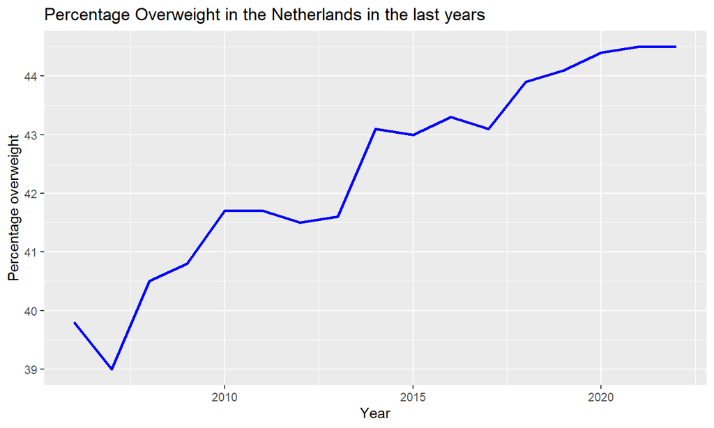

## Files of the assignment

The various files of the assignment can be found at the following locations:

- Shiny application: https://jolu1965.shinyapps.io/Assignment_week4_Developing_Data_Products/
- Github-files: https://github.com/Luijpejo/Assignment-Developing-Data-Products